# Lab 5 - Simulations

Jeremy Whorton

2/26/2019

## Normal Approximation to the Binomial

Recall that the Normal Approximation to the Binomial states that Binomial distributions are approximately Normally distributed, for a large enough number of trials and probability of success that is not close to 0% or 100%.

1. Generate 1000 samples from a Binomial distribution with 20 trials and a 90% probability of success.

```r
binom_samples <- data.frame(
  binom1 = rbinom(1000, size = 20, prob = .9)
)
```

1. Plot a histogram of these samples.

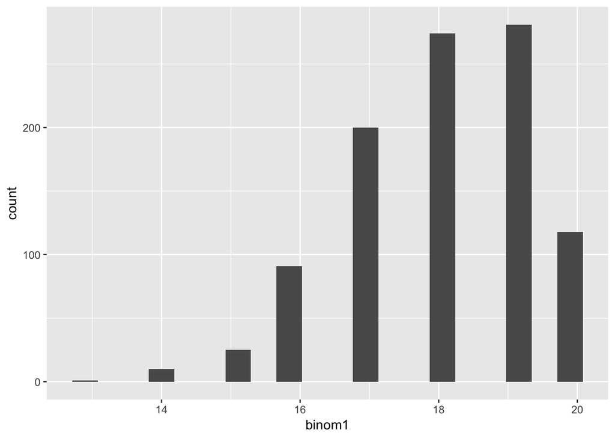

```r
ggplot(binom_samples, aes(x=binom1)) + geom_histogram(bins=20)
```

2. Plot a density from these samples.

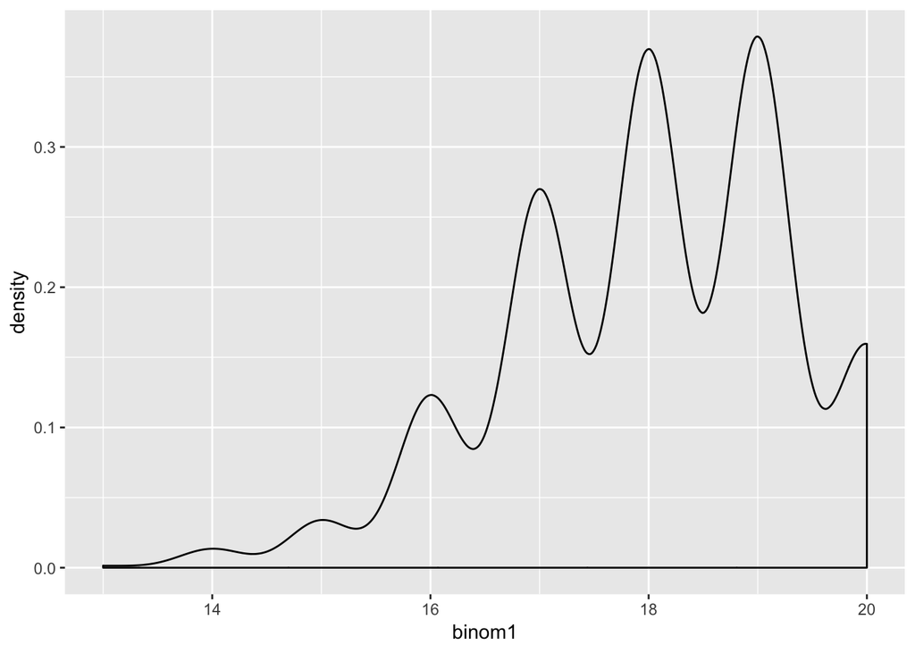

```r
ggplot(binom_samples, aes(x=binom1)) + geom_density()
```

2. Generate 1000 samples each from a Binomial distribution with
1. 20 trials, 90% chance of success
2. 20 trials, 70% chance of success
3. 20 trials, 50% chance of success Plot the densities of these results on top of each other in the same plot. .

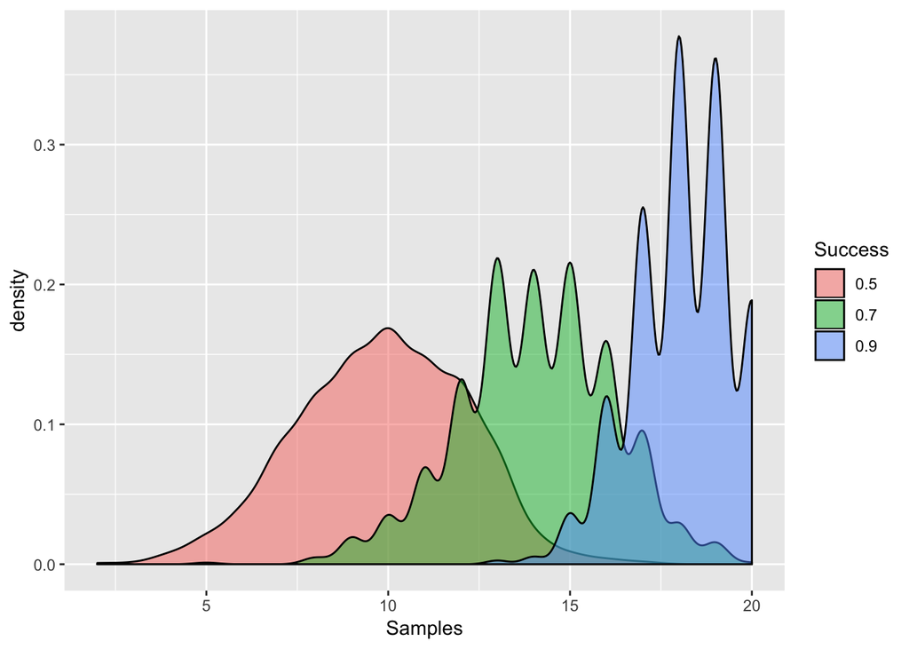

```r
probs = c(.9, .7, .5)
three_binoms <- map_dfc(probs, ~rbinom(1000, size = 20, prob = .x))
names(three_binoms) <- as.character(probs)
three_binoms <- three_binoms %>%
  gather(key = "Success", value = "Samples")

ggplot(three_binoms, aes(x=Samples, fill=Success)) + geom_density(alpha=0.5)
```

3. Generate 1000 samples each from a Binomial distribution with
1. 20 trials, 90% chance of success
2. 50 trials, 90% chance of success
3. 100 trials, 90% chance of success Convert these to sample proportions; i.e., if you observe a sample of 15 successes in 20 trials, that should be a sample proportion of 15/20 = 0.75. Plot the densities of the sample proportions on top of each other in the same plot.

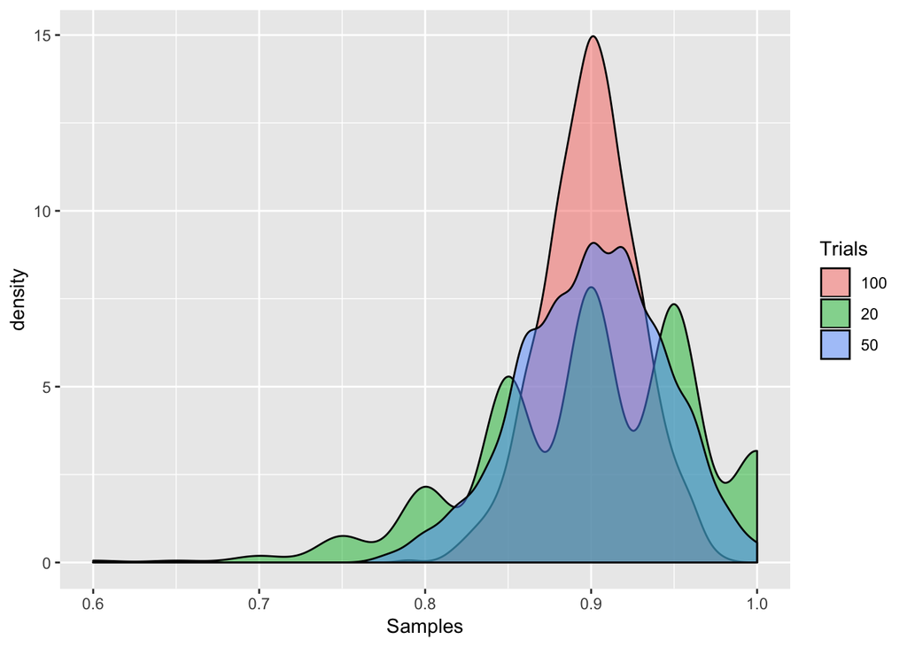

```r
trials = c(20, 50, 100)
three_trials <- map_dfc(trials, ~rbinom(1000, size = .x, prob = .9))
names(three_trials) <- as.character(trials)
three_trials <- three_trials %>%
  gather(key = "Trials", value = "Samples") %>%
  mutate(
    Samples = Samples/strtoi(Trials)
  )

ggplot(three_trials, aes(x=Samples, fill=Trials)) + geom_density(alpha=0.5)
```

4. Convert your code for generating and plotting the sample proportions to a function that takes two arguments: trials (a vector) and prob_success (a single value). The function should then plot the densities of the sample proportions for every value of trials that is supplied.

```r
gen_binom <- function(trials, prob_success) {
  trials_df <- map_dfc(trials, ~rbinom(1000, size = .x, prob = prob_success))
  names(trials_df) <- as.character(trials)
  trials_df <- trials_df %>%
    gather(key = "Trials", value = "Samples") %>%
    mutate(
      Samples = Samples/strtoi(Trials)
    )

  ggplot(trials_df, aes(x=Samples, fill=Trials)) + geom_density(alpha=1/length(trials))
}
```

5. Use your function and the resulting plots to come up with a “rule” for when the Normal Approximation to the Binomial makes sense.

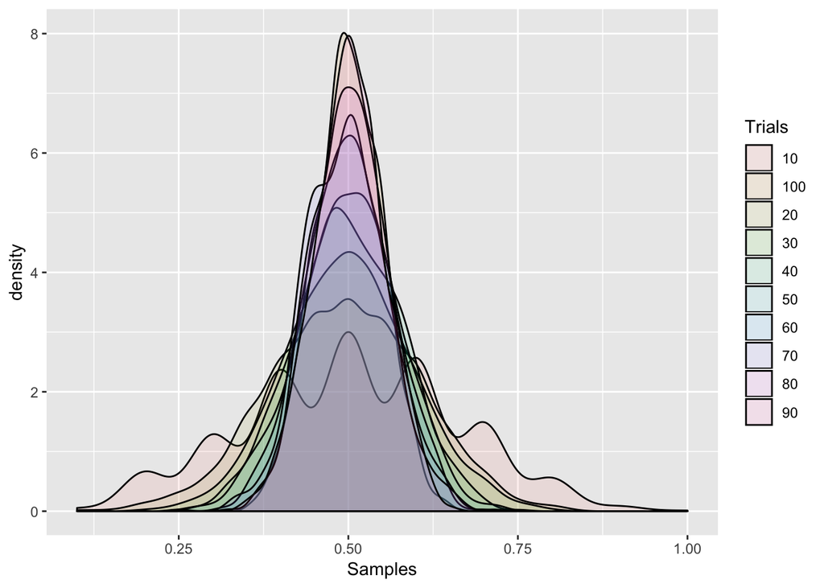

```r
gen_binom(c(10,20,30,40,50,60,70,80,90,100), .5)
```

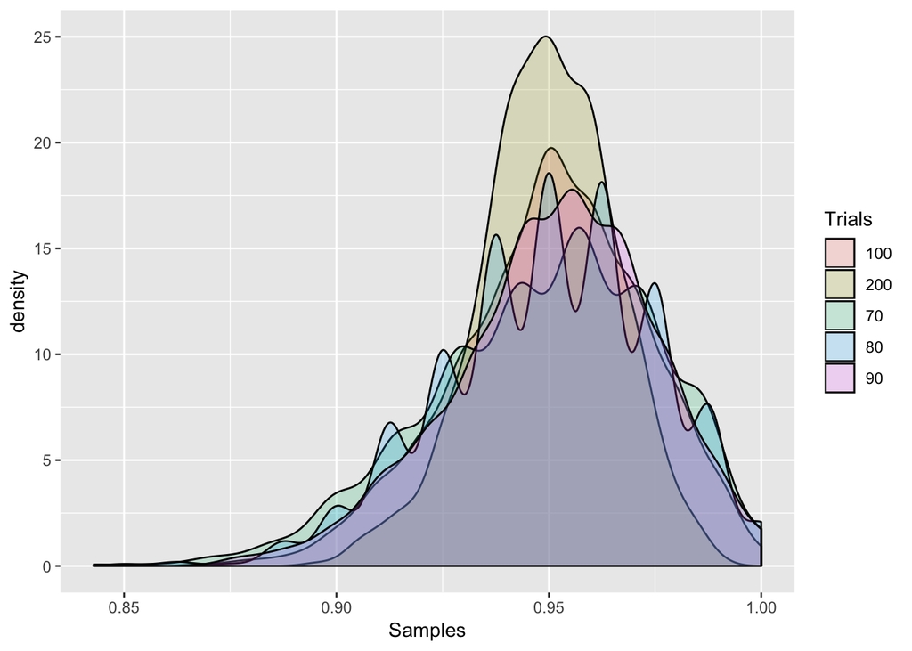

```r
gen_binom(c(70,80,90,100, 200), .95)
```

When the probability of success is near .5, it takes far less trials to approximate normal(25-35 trials); however, when the probability of success is farther out, towards the eddges, it takes upwards of 80 trials to generate a normal curve. A general rule would be a long the lines of:

trials to normal = (abs(prob - .5)*100)+30

## The Central Limit Theorem

Recall that the Central Limit Theorem tells us about the distribution of the sample mean, which is called the sampling distribution. As sample size becomes large, the sampling distribution approaches a normal distribution, and the standard deviation of the sampling distribution decreases. The mean of the sampling distribution is equal to the population mean.

Not all statistics have such nice theory and machinery to take advantage of! In the following exercise, you will explore the sampling distributions of a few different statistics: mean, median, standard deviation, range, and third quartile. (Note that the function range() in R does not compute the range as we intend it here.)

```r
samples = replicate(1000, rnorm(30, mean = 0, sd = 1), simplify = FALSE)

my_stats <- data.frame(
  mean = map_dbl(samples, mean),
  median = map_dbl(samples, median),
  std = map_dbl(samples, sd),
  range = map_dbl(samples, ~max(.x) - min(.x)),
  third = map_dbl(samples, ~quantile(.x, .75))
)
```

2. Plot the sampling distribution (histogram) of the means.

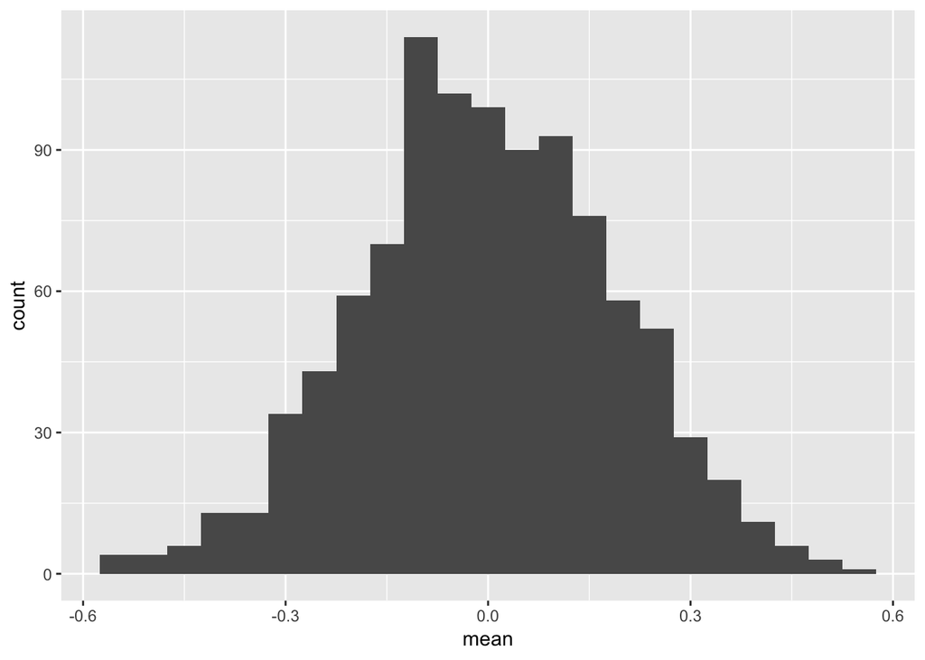

```r
ggplot(my_stats, aes(x=mean)) + geom_histogram(binwidth = .05)
```

3. Plot the sampling distributions of the other four statistics in (four separate graphs) of a single plotting window. Be sure to label things appropriately.

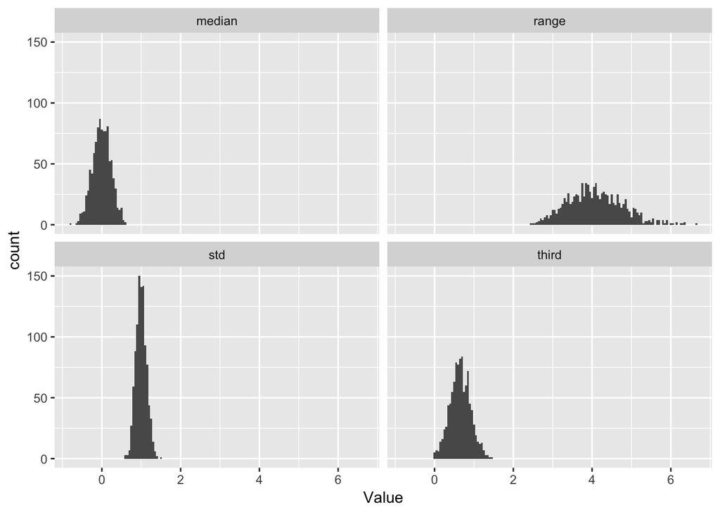

```r
my_stats %>%
  gather(key = "Stat", value = "Value") %>%
  filter(Stat != "mean") %>%
  ggplot(aes(x=Value)) + geom_histogram(binwidth = .05) + facet_wrap(~Stat)
```

2. Repeat (a)-(c) for a Uniform distribution with minimum of 10 and maximum of 90.

```r
unif_samples = replicate(1000, runif(30, min = 10, max = 90), simplify = FALSE)

unif_stats <- data.frame(
  mean = map_dbl(unif_samples, mean),
  median = map_dbl(unif_samples, median),
  std = map_dbl(unif_samples, sd),
  range = map_dbl(unif_samples, ~max(.x) - min(.x)),
  third = map_dbl(unif_samples, ~quantile(.x, .75))
)
```

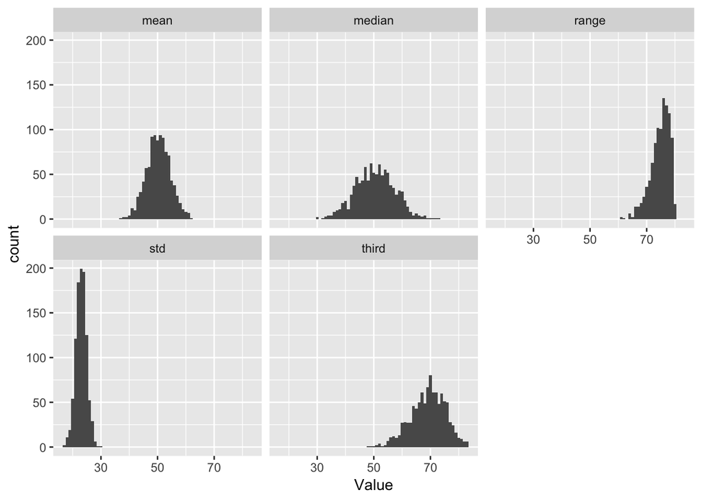

```r
unif_stats %>%
  gather(key = "Stat", value = "Value") %>%
  ggplot(aes(x=Value)) + geom_histogram(binwidth = 1) + facet_wrap(~Stat)
```

3. Based on the above, do you think that the Central Limit Theorem applies to any of the other statistics besides the mean? Justify your answer.